# Iris Species Classification

## Agenda:

1. Introduction
   - 1.1 Context
   - 1.2 Columns Description
   - 1.3 Objective
2. Data Preparation
   - 2.1 Packages & Helping Functions
   - 2.2 Data Loading
   - 2.3 Understanding Data
3. Data Cleaning
   - 3.1 Removing the id column
4. Exploratory Data Analysis
   - 4.1 Univariate Analysis
   - 4.2 Bivariate Analysis
5. Modeling
   - 6.1 Packages
   - 6.2 Splitting and Preprocessing
   - 6.3 Decision Tree
   - 6.4 Naïve Bayes
   - 6.5 AdaBoost
   - 6.6 Perceptron (a single level neural network)
   - 6.7 Random forests
6. Conclusion

# 1. Introduction

### 1.1 Context

The [dataset](https://www.kaggle.com/uciml/iris) includes three iris species with 50 samples each as well as some properties about each flower. One flower species is linearly separable from the other two, but the other two are not linearly separable from each other.

### 1.2 Columns Description

| Column | Description |
| --- | --- |
| Id | a unique number for each data entry |
| SepalLengthCm | Sepal Length given in cm |
| SepalWidthCm | Sepal Width given in cm |
| PetalLengthCm | Petal Length given in cm |
| PetalWidthCm | Petal Width given in cm |
| Species | The target value, takes one of three values (Iris-setosa / Iris-versicolor / Iris-virginica) |

### 1.3 Objective

Building a machine learning model to accurately predict the species of the flower based on its sepal and petal dimensions.

# 2. Data Preparation

### 2.1 Packages & Helping Functions

```python
# For Loading and Manipulating data
import pandas as pd
import numpy as np

# For visualization purposes
import matplotlib.pyplot as plt
import seaborn as sns

%matplotlib inline

# To evaluate different models
from sklearn.metrics import *

# To change the style of the plots ( so that all people can see the same colors )
plt.style.use('seaborn')
```

### 2.2 Data Loading

```python
df = pd.read_csv('Iris.csv')
```

### 2.3 Understanding Data

##### 2.3.1 Preview of the first five rows of the data

```python
df.head()
```

|  | Id | SepalLengthCm | SepalWidthCm | PetalLengthCm | PetalWidthCm | Species |
| --- | --- | --- | --- | --- | --- | --- |
| 0 | 1 | 5.1 | 3.5 | 1.4 | 0.2 | Iris-setosa |
| 1 | 2 | 4.9 | 3.0 | 1.4 | 0.2 | Iris-setosa |
| 2 | 3 | 4.7 | 3.2 | 1.3 | 0.2 | Iris-setosa |
| 3 | 4 | 4.6 | 3.1 | 1.5 | 0.2 | Iris-setosa |
| 4 | 5 | 5.0 | 3.6 | 1.4 | 0.2 | Iris-setosa |

#### 2.3.2 The shape of the data

```python
print(f"Shape of dataset: {df.shape}")
```

```
Shape of dataset: (150, 6)
```

#### 2.3.3 Columns info

```python
df.info()
```

```
<class 'pandas.core.frame.DataFrame'>
RangeIndex: 150 entries, 0 to 149
Data columns (total 6 columns):
 #   Column         Non-Null Count  Dtype
---  ------         --------------  -----
 0   Id             150 non-null    int64
 1   SepalLengthCm  150 non-null    float64
 2   SepalWidthCm   150 non-null    float64
 3   PetalLengthCm  150 non-null    float64
 4   PetalWidthCm   150 non-null    float64
 5   Species        150 non-null    object
dtypes: float64(4), int64(1), object(1)
memory usage: 7.2+ KB
```

#### 2.3.4 Summary statistics

```python
df.describe().T
```

|  | count | mean | std | min | 25% | 50% | 75% | max |
| --- | --- | --- | --- | --- | --- | --- | --- | --- |
| Id | 150.0 | 75.500000 | 43.445368 | 1.0 | 38.25 | 75.50 | 112.75 | 150.0 |
| SepalLengthCm | 150.0 | 5.843333 | 0.828066 | 4.3 | 5.10 | 5.80 | 6.40 | 7.9 |
| SepalWidthCm | 150.0 | 3.054000 | 0.433594 | 2.0 | 2.80 | 3.00 | 3.30 | 4.4 |
| PetalLengthCm | 150.0 | 3.758667 | 1.764420 | 1.0 | 1.60 | 4.35 | 5.10 | 6.9 |
| PetalWidthCm | 150.0 | 1.198667 | 0.763161 | 0.1 | 0.30 | 1.30 | 1.80 | 2.5 |

#### 2.3.5 Duplicates

```python
df.duplicated().sum()
```

```
0
```

## Summary

From the previous quick overview of the data we can conclude basic bullet points:

- The dataset is mostly clean.
- The 'Id' column is not needed.
- 'Species' is our only categorical column.
- There is no missing values or duplicates.

# 3. Data Cleaning

### 3.1 Removing the 'id' column

```python
df.drop(['Id'], axis=1, inplace = True)
```

```python
df.head()
```

|  | SepalLengthCm | SepalWidthCm | PetalLengthCm | PetalWidthCm | Species |
| --- | --- | --- | --- | --- | --- |
| 0 | 5.1 | 3.5 | 1.4 | 0.2 | Iris-setosa |
| 1 | 4.9 | 3.0 | 1.4 | 0.2 | Iris-setosa |
| 2 | 4.7 | 3.2 | 1.3 | 0.2 | Iris-setosa |
| 3 | 4.6 | 3.1 | 1.5 | 0.2 | Iris-setosa |
| 4 | 5.0 | 3.6 | 1.4 | 0.2 | Iris-setosa |

# 4. Exploratory Data Analysis

### 4.1 Univariate Analysis

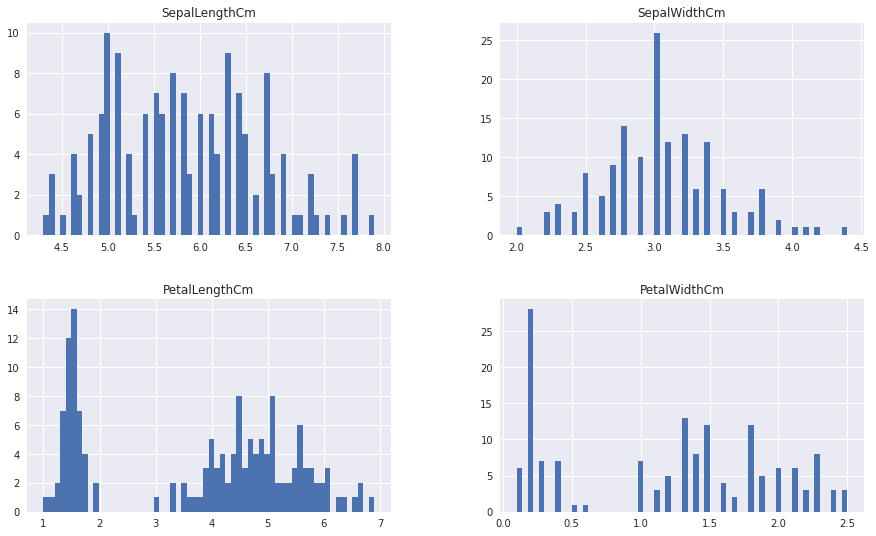

```python
df.hist(bins=60, figsize=(15,9));
plt.show()
```

### 4.2 Bivariate Analysis

Because the number of features are relatively small and all the features are numeric, we can plot a nicely looking heatmap and make use of it to investigate different relationships.

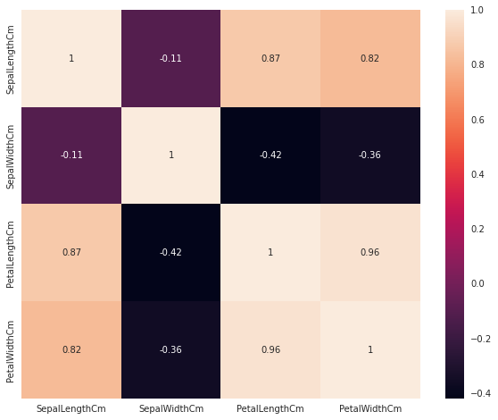

```python
plt.figure(figsize=(10,8))
sns.heatmap(df.corr(),annot=True)
plt.show()
```

Petal Width, Petal Length and Sepal Length are positively correlated.

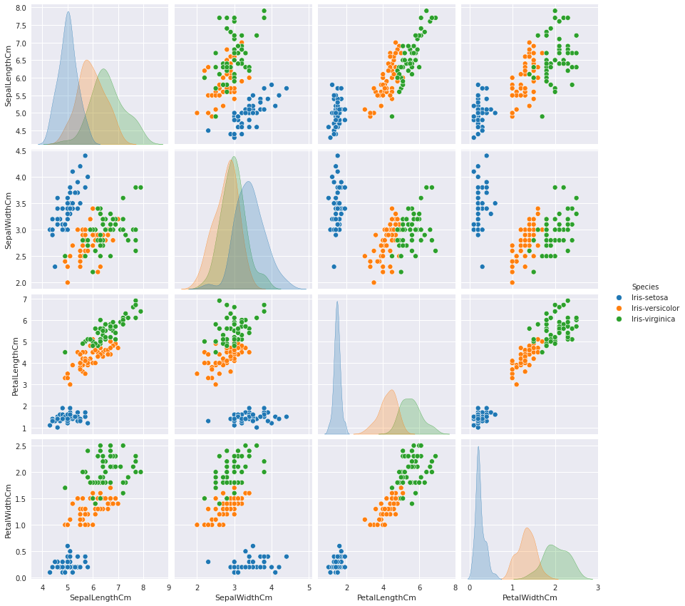

```python
g = sns.pairplot(df, hue='Species', palette = 'tab10', height = 3)
plt.show()
```

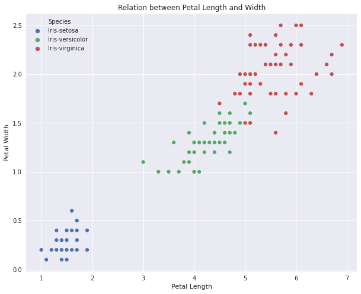

```python
plt.figure(figsize=(10,8))
fig = sns.scatterplot(data = df, x = 'PetalLengthCm', y = 'PetalWidthCm', hue = 'Species');
fig.set_xlabel("Petal Length")
fig.set_ylabel("Petal Width")
fig.set_title("Relation between Petal Length and Width")
plt.show();
```

Petal Features are giving a good cluster division

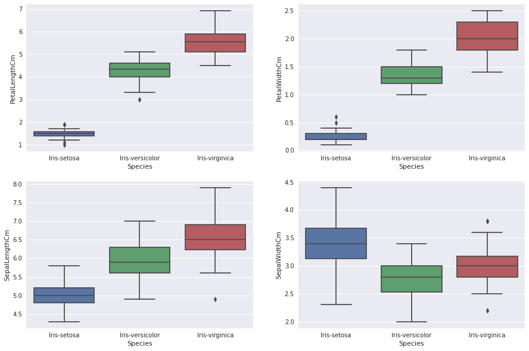

```python
plt.figure(figsize=(15,10))
plt.subplot(2,2,1)
sns.boxplot(x='Species',y='PetalLengthCm',data=df)
plt.subplot(2,2,2)
sns.boxplot(x='Species',y='PetalWidthCm',data=df)
plt.subplot(2,2,3)
sns.boxplot(x='Species',y='SepalLengthCm',data=df)
plt.subplot(2,2,4)
sns.boxplot(x='Species',y='SepalWidthCm',data=df)
plt.show();
```

# 6. Modeling

### 6.1 Packages

```python
import mlpack
```

### 6.2 Splitting and Preprocessing

Preprocessing

```python
df['Species'] = df['Species'].astype('category')
```

```python
df['Species'] = df['Species'].cat.codes
```

```python
features = ["SepalLengthCm", "SepalWidthCm", "PetalLengthCm", "PetalWidthCm"]
```

```python
X = df[features]
y = df["Species"]
```

Splitting

```python
def TrainTestSplit(features, target, test_ratio=0.2, standardize=False):
    """
    Splits the features & target into respective training and test set based on the test ratio.

        Parameter:
            features (DataFrame): Pandas dataframe containing the features.
            target (DataFrame): Pandas dataframe containing the targets.
            test_ratio (double): Percentage of dataset to be hold out for test set. default 20%.
            standardize (bool): if True, features are scaled, default False.

        Returns:
            Xtrain (DataFrame): Pandas dataframe containing training features.
            Xtest (DataFrame): Pandas dataframe containing test features.
            ytrain (DataFrame): Pandas dataframe containing training targets.
            ytest (DataFrame): Pandas dataframe containing test targets.
    """
    train_len = len(features)
    train_idxs = list(range(train_len))
    np.random.shuffle(train_idxs)
    split = int(np.floor(test_ratio * train_len))
    Xtest = features.iloc[train_idxs[:split], :].values
    Xtrain = features.iloc[train_idxs[split:], :].values
    ytest = target.iloc[train_idxs[:split]].values
    ytrain = target.iloc[train_idxs[split:]].values
    if standardize:
        # Normalize Features.
        Xtrain = StandardScaler(Xtrain)
        Xtest = StandardScaler(Xtest)
    return Xtrain, Xtest, ytrain, ytest



def StandardScaler(data):
    """
    Standardize features by removing the mean and scaling to unit variance.

        Parameter:
            data (Dataframe): Pandas dataframe whose features must be scaled.

        Returns:
            data (Dataframe): Pandas dataframe with scaled features.
    """
    for col in range(data.shape[1]):
        data[:, col] = (data[:, col] - data[:,col].mean()) / (data[:,col].std())
    return data
```

```python
Xtrain, Xtest, ytrain, ytest = TrainTestSplit(X, y, 0.2)
```

```python
print(f"The shape of Xtrain is      {Xtrain.shape}")
print(f"The shape of Xtest is       {Xtest.shape}")
print(f"The shape of ytrain is      {ytrain.shape}")
print(f"The shape of ytest is       {ytest.shape}")
```

```
The shape of Xtrain is      (120, 4)
The shape of Xtest is       (30, 4)
The shape of ytrain is      (120,)
The shape of ytest is       (30,)
```

### 6.3 Decision Tree

Predicting values

```python
output = mlpack.decision_tree(training=Xtrain, labels=ytrain, print_training_accuracy=True)
dt_model = output["output_model"]
```

```python
predictions = mlpack.decision_tree(input_model=dt_model, test=Xtest)
```

```python
yPreds = predictions["predictions"].reshape(-1, 1).squeeze()
```

#### Evaluation metrics

- True Positive - The actual value was true & the model predicted true.
- False Positive - The actual value was false & the model predicted true, Type I error.
- True Negative - The actual value was false & the model predicted false.
- False Negative - The actual value was true & the model predicted false, Type II error.

`Accuracy`: is a metric that generally describes how the model performs across all classes. It is useful when all classes are of equal importance. It is calculated as the ratio between the number of correct predictions to the total number of predictions.

$$Accuracy = \frac{True_{positive} + True_{negative}}{True_{positive} + True_{negative} + False_{positive} + False_{negative}}$$

`Precision`: is calculated as the ratio between the number of positive samples correctly classified to the total number of samples classified as Positive. The precision measures the model's accuracy in classifying a sample as positive.

$$Precision = \frac{True_{positive}}{True_{positive} + False_{positive}}$$

`Recall`: is calulated as the ratio between the number of positive samples correctly classified as Positive to the total number of Positive samples. The recall measures the model's ability to detect Positive samples. The higher the recall, the more positive samples detected.

$$Recall = \frac{True_{positive}}{True_{positive} + False_{negative}}$$

`Confusion matrix`: A technique used for summarizing the performance of a classification algorithm.

[figure not shown]

- The decision of whether to use precision or recall depends on the type of problem begin solved.
- If the goal is to detect all positive samples then use recall.
- Use precision if the problem is sensitive to classifying a sample as Positive in general.

Results

```python
def modelEval(ytest, yPreds):
    print(f"Accuracy: {accuracy_score(ytest, yPreds)}")
    print(f"Cohen's Kappa: {cohen_kappa_score(ytest, yPreds)}")
    print(f"Recall Score: {recall_score(ytest,yPreds, average = 'micro')}")
    print(f"Precision Score: {precision_score(ytest,yPreds, average = 'micro')}")
    cm = confusion_matrix(ytest,yPreds)
    sns.heatmap(cm,annot=True,fmt="d", center=0, cmap='autumn')
    plt.title("Confusion Matrix")
    plt.ylabel('True label')
    plt.xlabel('Predicted label')
    plt.show()
```

```
Accuracy: 0.9333333333333333
Cohen's Kappa: 0.8969072164948454
Recall Score: 0.9333333333333333
Precision Score: 0.9333333333333333
```

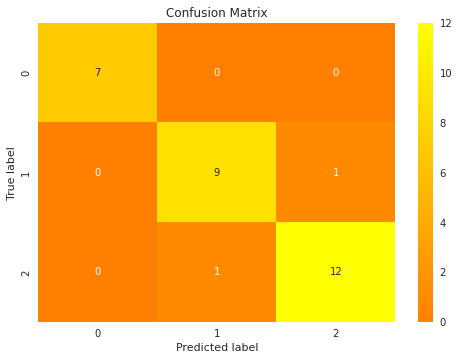

```python
modelEval(ytest, yPreds)
```

### 6.4 Naïve Bayes

Predicting values

```python
output = mlpack.nbc(training=Xtrain, labels=ytrain)
nbc_model = output["output_model"]
```

```python
predictions = mlpack.nbc(input_model=nbc_model, test=Xtest)
```

```python
yPreds = predictions["predictions"].reshape(-1, 1).squeeze()
```

Results

```
Accuracy: 0.9666666666666667
Cohen's Kappa: 0.9481865284974094
Recall Score: 0.9666666666666667
Precision Score: 0.9666666666666667
```

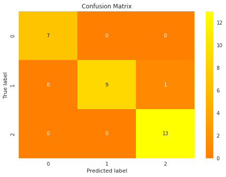

```python
modelEval(ytest, yPreds)
```

### 6.5 AdaBoost

Predicting values

```python
output = mlpack.adaboost(training=Xtrain, labels=ytrain, weak_learner="decision_stump")
ab = output["output_model"]
```

```python
predictions = mlpack.adaboost(input_model=ab, test=Xtest)
```

```python
yPreds = predictions["predictions"].reshape(-1, 1).squeeze()
```

Results

```
Accuracy: 0.9333333333333333
Cohen's Kappa: 0.8969072164948454
Recall Score: 0.9333333333333333
Precision Score: 0.9333333333333333
```

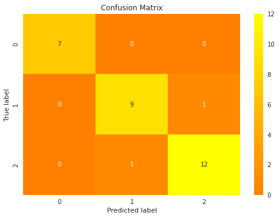

```python
modelEval(ytest, yPreds)
```

### 6.6 Perceptron (a single level neural network)

Predicting values

```python
output = mlpack.perceptron(training=Xtrain, labels=ytrain)
p_model = output["output_model"]
```

```python
predictions = mlpack.perceptron(input_model= p_model, test=Xtest)
```

```python
yPreds = predictions["predictions"].reshape(-1, 1).squeeze()
```

Results

```
Accuracy: 0.9666666666666667
Cohen's Kappa: 0.9481865284974094
Recall Score: 0.9666666666666667
Precision Score: 0.9666666666666667
```

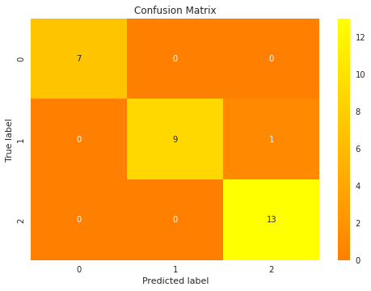

```python
modelEval(ytest, yPreds)
```

### 6.7 Random forests

Predicting values

```python
output = mlpack.random_forest(training=Xtrain, labels=ytrain)
rf_model = output["output_model"]
```

```python
predictions = mlpack.random_forest(input_model= rf_model, test=Xtest)
```

```python
yPreds = predictions["predictions"].reshape(-1, 1).squeeze()
```

Results

```
Accuracy: 0.9
Cohen's Kappa: 0.8461538461538461
Recall Score: 0.9
Precision Score: 0.9
```

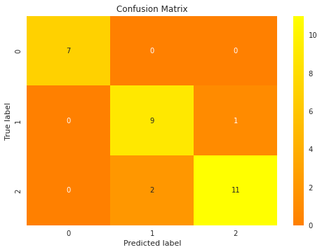

```python
modelEval(ytest, yPreds)
```

# 7. Conclusion

As we can see all the 5 models used in this notebook perform quite similarly on this dataset.

- **Accuracy:** Generally above 0.9

Keep in mind that this dataset is very small (150 entries) so the results change every time you run the notebook